# Project_Mollusca

just_student

10/8/2020

# Оценка параметров размера и веса у моллюсков разного пола и возраста

Необходимые нам библиотеки:

```r
options(encoding = "UTF-8")

PkgNames <- c("dplyr", "magrittr", "ggplot2", "reshape2", "purrr","utf8", "outliers", "DescTools")
new.packages <- PkgNames[!(PkgNames %in% installed.packages()[,"Package"])]
if(length(new.packages)) install.packages(new.packages)

invisible(suppressMessages(suppressWarnings(lapply(PkgNames, require, character.only = T))))
```

## Краткое описание проекта

Цель исследования: данный проект представляет собой попытку проанализировать данные, характеризующиее выборку беломорских мидий и описывающие их размер, вес, пол и возраст.

Задачи:

1. Провести первичный анализ данных на предмет ошибок,пропущенных и некорректных значений.
2. Оценить параметры распределения переменных, характеризующих вес и размер моллюска, и выявить коррелирующие признаки.
3. Оценить влияние возраста и пола моллюска на параметры размера и веса
4. Попытаться выявить наличие взаимосвязи между переменными, характеризующими размер и вес моллюсков.

### Dataframe generation

```r
abs_way <- getwd()
abs_way <- normalizePath(abs_way)
data_files<- list.files(abs_way, pattern =".csv")
Mollusca <- list()
for(i in 1:length(data_files)){
file <- read.table(data_files[i], header=TRUE, sep=",", stringsAsFactors=TRUE)
Mollusca <- rbind(Mollusca, file)
}
str(Mollusca)
```

```
## 'data.frame':    4177 obs. of  9 variables:
##  $ Rings                                 : chr  "18" "14" "8" "12" ...
##  $ Sex..1...male..2...female..3...uvenil.: chr  "2" "3" "1" "1" ...
##  $ Length                                : chr  "0.575" "0.385" "0.475" "0.665" ...
##  $ Diameter                              : num  0.45 0.305 0.37 0.525 0.12 0.16 0.565 0.43 0.175 0.3 ...
##  $ Height                                : num  0.17 0.095 0.125 0.18 0.075 0.05 0.2 0.15 0.055 0.115 ...
##  $ Whole_weight                          : num  1.048 0.252 0.649 1.429 0.117 ...
##  $ Shucked_weight                        : num  0.3775 0.0915 0.347 0.6715 0.0455 ...
##  $ Viscera_weight                        : num  0.171 0.055 0.136 0.29 0.029 ...
##  $ Shell_weight                          : num  0.385 0.09 0.142 0.4 0.0345 0.015 0.494 0.221 0.018 0.0935 ...
```

### Работа с переменными

Переименуем вторую переменную нашего датафрейма “Sex..1…male..2…female..3…uvenil.” в переменную ‘Sex’.

```r
colnames(Mollusca)[colnames(Mollusca) == 'Sex..1...male..2...female..3...uvenil.'] <- 'Sex'
colnames(Mollusca)
```

```
## [1] "Rings"          "Sex"            "Length"         "Diameter"
## [5] "Height"         "Whole_weight"   "Shucked_weight" "Viscera_weight"
## [9] "Shell_weight"
```

```r
Mollusca %>% select_all() %>%summarise_all(funs(sum(is.na(.))))
```

```
##   Rings Sex Length Diameter Height Whole_weight Shucked_weight Viscera_weight
## 1     0   1      6        5      2            1              3              0
##   Shell_weight
## 1            2
```

Далее, изменим тип переменной Diameter на numeric. Т.к.в нашем датасете есть еще 2 переменные строкового типа, а именно Lenght и Rings, то проверим их на уникальные элементы.

```r
Mollusca$Diameter <-  as.numeric(Mollusca$Diameter,quietly = TRUE) #convert  in numeric type
Rings <- unique(Mollusca$Rings)
print(Rings[29])
```

```
## [1] "nine"
```

```r
Length <- unique(Mollusca$Length)
print(Length[134])
```

```
## [1] "No data! I forgot to mesure it!("
```

Как мы видим, в интересующих нас колонках обнаруживаются некорректные наблюдения. Заменим значения этих наблюдений на корректные, либо на NA. Проверим наши данные на количество пропущенных значений, оно увеличилось на 1.

```r
Mollusca$Rings[Mollusca$Rings == "nine"] <- "9"
Mollusca$Length[Mollusca$Length == "No data! I forgot to mesure it!("] <- NA

Mollusca$Rings <- as.numeric(Mollusca$Rings, quietly = TRUE)
Mollusca$Length <-  as.double(Mollusca$Length, queitly = TRUE)
Mollusca %>% select_all() %>% summarise_all(funs(sum(is.na(.))))
```

```
##   Rings Sex Length Diameter Height Whole_weight Shucked_weight Viscera_weight
## 1     0   1      7        5      2            1              3              0
##   Shell_weight
## 1            2
```

Найдем все уникальные значения для переменной Sex и выведем их. Как мы видим, в этой переменной тоже присутствуют некорректные значения.

```r
sex <- unique(Mollusca$Sex)
print(sex)#check for unique values
```

```
## [1] "2"     "3"     "1"     NA      "three" "one"   "male"
```

Как и в предыдущем случае, у нас есть ошибки в данных, исправим их на корректный формат. Затем сконвертируем переменную Sex в фактор с тремя градациями: Male, Female, Uvenile. Выведем структуру получившегося датасета.

```r
Mollusca$Sex[Mollusca$Sex == "three"] <- "3"
Mollusca$Sex[Mollusca$Sex == "one"] <- "1"
Mollusca$Sex[Mollusca$Sex == "male"] <- "1"
sex_new <- unique(Mollusca$Sex) #after changing the uncorrect values
Mollusca$Sex <- factor(Mollusca$Sex, levels = c("1", "2","3"), labels = c("Male", "Female", "Uvenile"))
Mollusca <- Mollusca[complete.cases(Mollusca$Sex),]
str(Mollusca)
```

```
## 'data.frame':    4176 obs. of  9 variables:
##  $ Rings         : num  18 14 8 12 4 4 12 8 6 8 ...
##  $ Sex           : Factor w/ 3 levels "Male","Female",..: 2 3 1 1 3 3 1 2 3 2 ...
##  $ Length        : num  0.575 0.385 0.475 0.665 0.28 0.22 0.72 0.55 0.235 0.4 ...
##  $ Diameter      : num  0.45 0.305 0.37 0.525 0.12 0.16 0.565 0.43 0.175 0.3 ...
##  $ Height        : num  0.17 0.095 0.125 0.18 0.075 0.05 0.2 0.15 0.055 0.115 ...
##  $ Whole_weight  : num  1.048 0.252 0.649 1.429 0.117 ...
##  $ Shucked_weight: num  0.3775 0.0915 0.347 0.6715 0.0455 ...
##  $ Viscera_weight: num  0.171 0.055 0.136 0.29 0.029 ...
##  $ Shell_weight  : num  0.385 0.09 0.142 0.4 0.0345 0.015 0.494 0.221 0.018 0.0935 ...
```

### Идентификация выбросов

Идентифицируем все выбросы в наших данных и создадим на их основе список List_of_outl. Как мы видим из структуры списка, наибольшее количество выбросов приходится на переменную Rings. Найдем все уникальные значения выбросов в Rings и выведем их. Очевидно, что туда попадают совсем юные (до 3 лет) и старые животные (больше 16 лет). Не будем выбрасывать эти данные совсем, лучше сформируем из них отдельные группы.

```r
outliers <- function(dataframe){
  dataframe %>%
      select_if(is.numeric) %>%
      map(~ boxplot.stats(.x)$out)
}
List_of_outl <- outliers(Mollusca)
str(List_of_outl)
```

```
## List of 8
##  $ Rings         : num [1:278] 18 20 17 20 18 18 3 16 16 16 ...
##  $ Length        : num [1:49] 0.155 0.165 0.17 0.165 0.16 0.2 0.19 0.13 0.165 0.16 ...
##  $ Diameter      : num [1:58] 0.12 0.105 0.12 0.13 0.15 0.115 0.12 0.145 0.15 0.13 ...
##  $ Height        : num [1:29] 0.03 0.015 0.02 0.25 0.03 0.03 0.03 0 0.025 0.025 ...
##  $ Whole_weight  : num [1:30] 2.22 2.83 2.25 2.38 2.24 ...
##  $ Shucked_weight: num [1:48] 1.017 1.083 1.147 0.984 0.992 ...
##  $ Viscera_weight: num [1:25] 0.55 0.519 0.5 0.525 0.564 ...
##  $ Shell_weight  : num [1:35] 0.63 0.897 0.66 0.655 0.797 ...
```

```r
uniq_Rings_out <- unique(List_of_outl$Rings)
print(uniq_Rings_out)
```

```
##  [1] 18 20 17  3 16 19 23 29 22 21  2 25 27 24  1 26
```

### Оценка наличия выбросов в переменных с помощью графика боксплот

Построим графики распределения наших переменных в зависимости от пола. Можно заметить, что значения всех параметров для группы “Uvenile” меньше, чем для половозрелых особей. Возможно, это связано с тем, что ювенильные животные в целом моложе своих половозрелых сородичей.

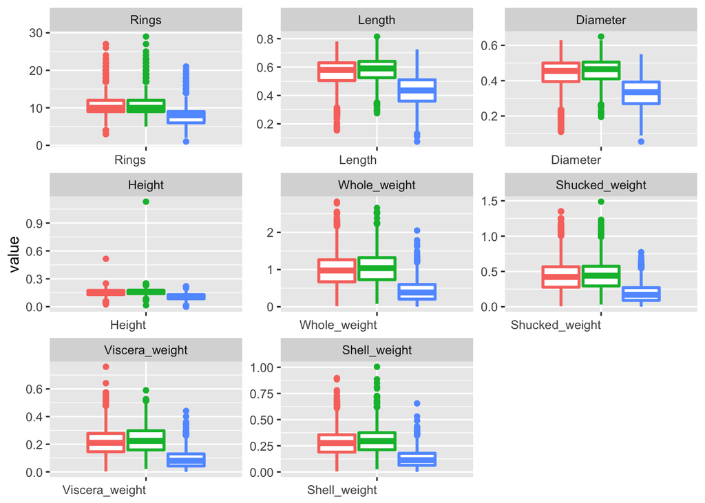

```r
size_weight = melt(Mollusca, id.vars = "Sex", measure.vars = c("Rings","Length", "Diameter", "Height", "Whole_weight", "Shucked_weight", "Viscera_weight", "Shell_weight"), quietly = TRUE)
ggplot(size_weight, aes(x = variable,y = value, col = Sex),quietly = TRUE) + facet_wrap(~variable, scale="free") + geom_boxplot( size = 1)+ labs( y = "value", x = NULL) + theme(axis.text.x = element_text(angle=0, hjust=1, vjust=0.5))+ theme(legend.position = "righ")
```

Уберем выбросы во всех нумерических переменных, кроме Rings. Для этого заменим их на пропущенные значения, которые затем удалим.

```r
 Mollusca_clean <- Mollusca[,3:9] %>%
           map_if(is.numeric, ~ replace(.x, .x %in% boxplot.stats(.x)$out, NA)) %>%
           bind_cols
Mollusca %>% summarise_all(funs( sum(is.na(.))))
```

```
##   Rings Sex Length Diameter Height Whole_weight Shucked_weight Viscera_weight
## 1     0   0      7        5      2            1              3              0
##   Shell_weight
## 1            2
```

```r
Mollusca <- Mollusca[complete.cases(Mollusca_clean),]
```

На основе переменной Rings, отображающей количество годовых колец на раковине моллюсков,создадим еще одну факторную переменную, разбивающую все наши наблюдения на 4 группы: “baby”, “young”,“adult”,“old”

```r
Mollusca <- mutate(Mollusca, Age = case_when(Rings <=5 ~ 1,
                       (Rings >= 6 & Rings <= 10) ~ 2,
                       (Rings >= 11 & Rings <= 15) ~ 3,
                       (Rings >= 16 & Rings <=30) ~ 4))

Mollusca$Age <- factor(Mollusca$Age, levels = c(1,2,3,4), labels = c("baby", "young","adult","old"))
```

### Оценка нормальности распределения данных

Проверим все наши нумерические переменные на нормальность распределения и построим их гистограммы. Для проверки на нормальность будем использовать тест Шапиро-Уилка. На графиках отобразим распределения признаков, сгруппированных по полу и возрасту. Как видно из таблицы и графика, данные имеют ненормальное распределение (Ha), поэтому для дальнейшего анализа необходимо использовать непараметрические критерии.

```r
shapiro_test_df <- function(df, bonf= FALSE, alpha= 0.05) {
        l <- lapply(df, shapiro.test)
        s <- do.call("c", lapply(l, "[[", 1))
        p <- do.call("c", lapply(l, "[[", 2))
        if (bonf == TRUE) {
                sig <- ifelse(p > alpha / length(l), "H0", "Ha")
        } else {
                sig <- ifelse(p > alpha, "H0", "Ha")
        }
        return(list(statistic= s,
                    p.value= p,
                    significance= sig,
                    method= ifelse(bonf == TRUE, "Shapiro-Wilks test with Bonferroni Correction",
                                   "Shapiro-Wilks test without Bonferroni Correction")))
}

Mollusca  %>% select(where(is.numeric)) %>% shapiro_test_df()
```

```
## $statistic
##          Rings.W         Length.W       Diameter.W         Height.W
##        0.9209652        0.9693052        0.9693890        0.9909709
##   Whole_weight.W Shucked_weight.W Viscera_weight.W   Shell_weight.W
##        0.9760995        0.9723230        0.9724641        0.9783236
##
## $p.value
##          Rings         Length       Diameter         Height   Whole_weight
##   1.254195e-41   1.890922e-28   2.046378e-28   2.796231e-15   2.112949e-25
## Shucked_weight Viscera_weight   Shell_weight
##   3.628647e-27   4.190630e-27   2.918993e-24
##
## $significance
##          Rings         Length       Diameter         Height   Whole_weight
##           "Ha"           "Ha"           "Ha"           "Ha"           "Ha"
## Shucked_weight Viscera_weight   Shell_weight
##           "Ha"           "Ha"           "Ha"
##
## $method
## [1] "Shapiro-Wilks test without Bonferroni Correction"
```

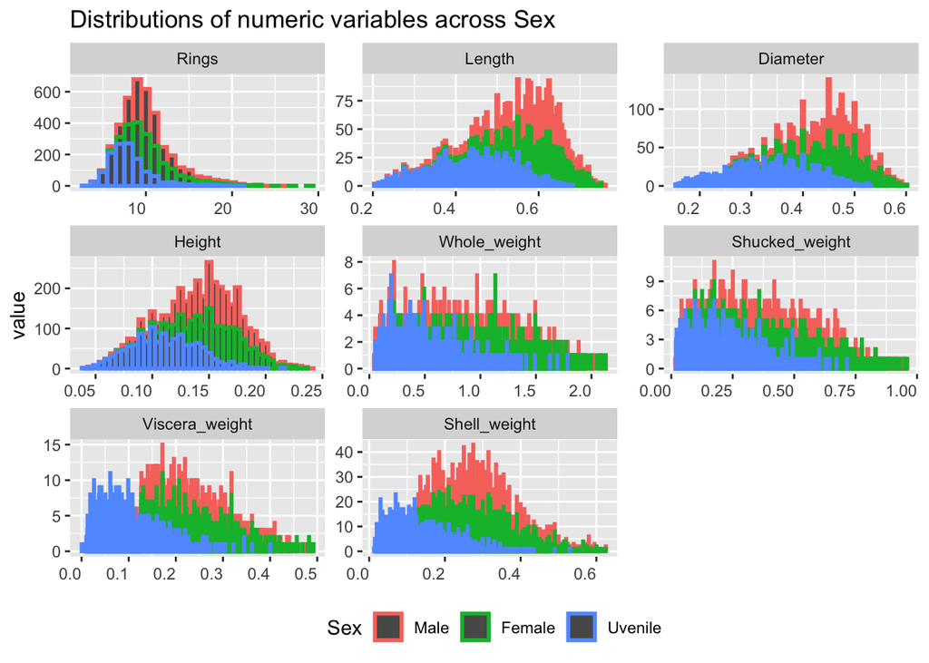

```r
size_weight <- melt(Mollusca, id.vars = c("Sex","Age"), measure.vars = c("Rings","Length", "Diameter", "Height", "Whole_weight", "Shucked_weight", "Viscera_weight", "Shell_weight"), quietly = TRUE)

ggplot(size_weight, aes(x = value, col=Sex),quietly = TRUE) + facet_wrap(~variable, scale="free") + geom_histogram(size = 1,stat = "count")+ labs( y = "value", x = NULL) + theme(axis.text.x = element_text(angle=0, hjust=1, vjust=0.5))+ theme(legend.position = "bottom")+labs(title = "Distributions of numeric variables across Sex")
```

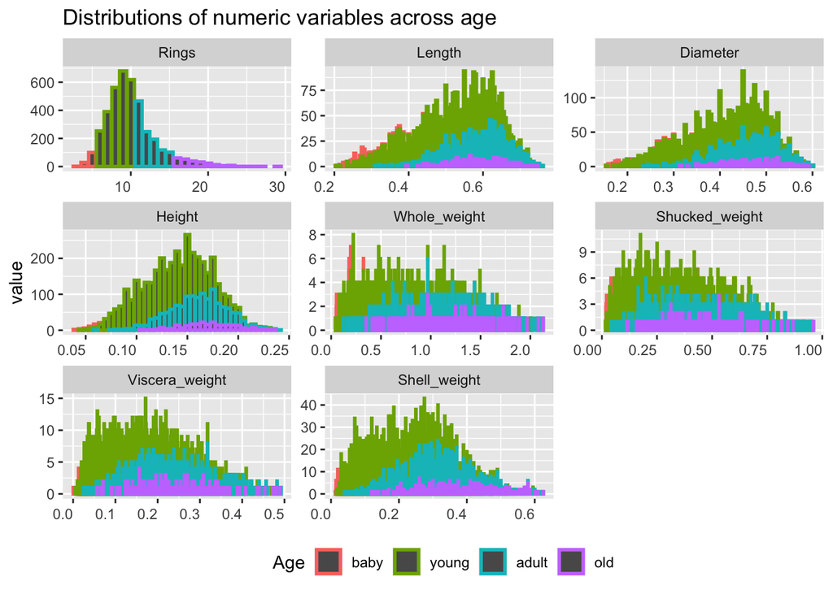

```r
ggplot(size_weight, aes(x = value, col=Age),quietly = TRUE) + facet_wrap(~variable, scale="free") + geom_histogram(size = 1,stat = "count")+ labs( y = "value", x = NULL) + theme(axis.text.x = element_text(angle=0, hjust=1, vjust=0.5))+ theme(legend.position = "bottom")+labs(title = "Distributions of numeric variables across age")
```

```r
cor(Mollusca[,c(1,3:9)], method = "spearman")
```

```
##                    Rings    Length  Diameter    Height Whole_weight
## Rings          1.0000000 0.5788452 0.5988366 0.6366637    0.6069051
## Length         0.5788452 1.0000000 0.9818764 0.8802010    0.9702574
## Diameter       0.5988366 0.9818764 1.0000000 0.8882427    0.9687313
## Height         0.6366637 0.8802010 0.8882427 1.0000000    0.9093670
## Whole_weight   0.6069051 0.9702574 0.9687313 0.9093670    1.0000000
## Shucked_weight 0.5091564 0.9527627 0.9458182 0.8636849    0.9747989
## Viscera_weight 0.5904254 0.9483452 0.9437282 0.8930951    0.9730903
## Shell_weight   0.6741911 0.9442631 0.9509039 0.9160405    0.9670793
##                Shucked_weight Viscera_weight Shell_weight
## Rings               0.5091564      0.5904254    0.6741911
## Length              0.9527627      0.9483452    0.9442631
## Diameter            0.9458182      0.9437282    0.9509039
## Height              0.8636849      0.8930951    0.9160405
## Whole_weight        0.9747989      0.9730903    0.9670793
## Shucked_weight      1.0000000      0.9424174    0.9104406
## Viscera_weight      0.9424174      1.0000000    0.9333601
## Shell_weight        0.9104406      0.9333601    1.0000000
```

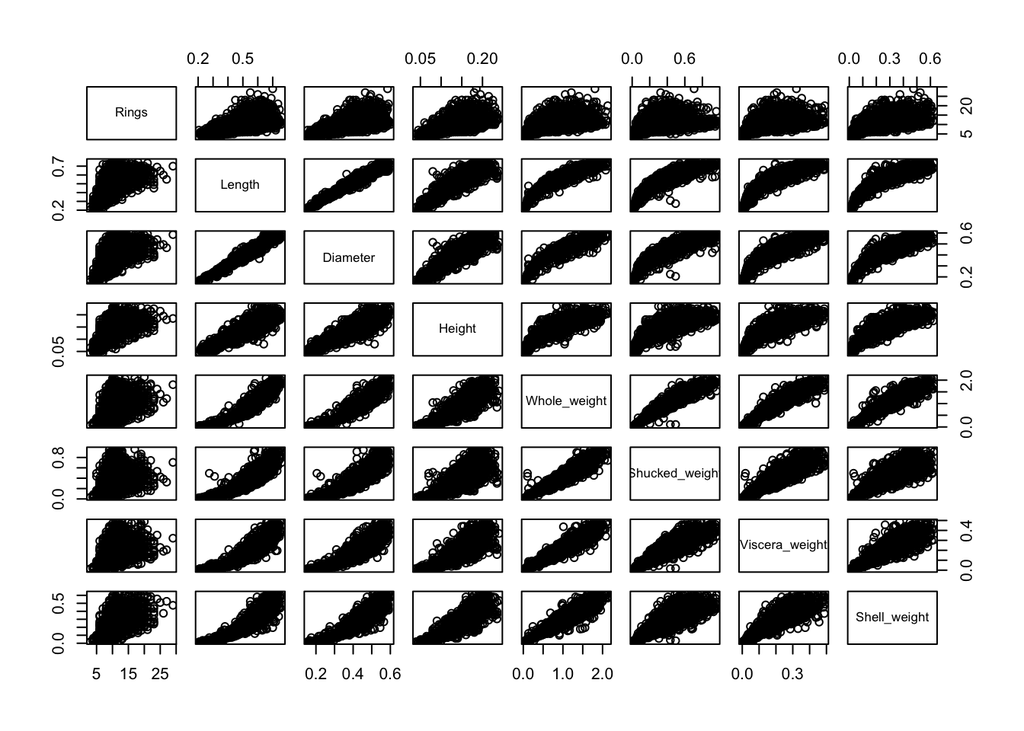

```r
pairs(Mollusca[,c(1,3:9)])
```

### Расчет статистических показателей распределения переменных в зависимости от пола и возраста моллюсков

Расчитаем статистические показатели распределения для переменных Diameter и Whole_weight для групп животных разного пола и возраста.

```r
Diam <- aggregate(Diameter ~ Sex + Age, data = Mollusca, function(x) c (mean = mean(x),median = median(x),sd = sd(x),first_quant = quantile(x,0.25), third_quant = quantile(x,0.75)))
Wheight <- aggregate(Whole_weight ~ Sex + Age, data = Mollusca, function(x) c (mean = mean(x),median = median(x),sd = sd(x),first_quant = quantile(x,0.25),third_quant = quantile(x,0.75)))

Sum_Diam <- cbind(Diam[-ncol(Diam)], Diam[[ncol(Diam)]])
Sum_Wheight <- cbind(Wheight[-ncol(Wheight)], Wheight[[ncol(Wheight)]])
print(Sum_Diam)
```

```
##        Sex   Age      mean median         sd first_quant.25% third_quant.75%
## 1     Male  baby 0.2081818 0.2050 0.03736795         0.19000         0.21250
## 2   Female  baby 0.2412500 0.2475 0.03816084         0.21750         0.27125
## 3  Uvenile  baby 0.2139655 0.2075 0.03980669         0.18375         0.23500
## 4     Male young 0.4207669 0.4400 0.07966582         0.37500         0.47500
## 5   Female young 0.4368482 0.4500 0.06890963         0.39500         0.48500
## 6  Uvenile young 0.3362760 0.3400 0.06938202         0.28000         0.38500
## 7     Male adult 0.4609145 0.4700 0.06567803         0.42000         0.51000
## 8   Female adult 0.4693016 0.4800 0.06359791         0.42500         0.51500
## 9  Uvenile adult 0.4084733 0.4150 0.05933896         0.36000         0.45000
## 10    Male   old 0.4728774 0.4750 0.05403239         0.43500         0.51500
## 11  Female   old 0.4707658 0.4750 0.05995149         0.42500         0.52000
## 12 Uvenile   old 0.4310417 0.4375 0.05593045         0.38750         0.46875
```

```r
print(Sum_Wheight)
```

```
##        Sex   Age      mean  median         sd first_quant.25% third_quant.75%
## 1     Male  baby 0.1150909 0.09400 0.07379391        0.084750        0.111250
## 2   Female  baby 0.1622500 0.16425 0.06848905        0.125000        0.201500
## 3  Uvenile  baby 0.1247284 0.10575 0.06922868        0.073000        0.151875
## 4     Male young 0.8643621 0.87600 0.39562426        0.563000        1.138500
## 5   Female young 0.9322975 0.93675 0.37165473        0.655750        1.198750
## 6  Uvenile young 0.4340480 0.40000 0.23134113        0.243250        0.584000
## 7     Male adult 1.0821342 1.08900 0.39576956        0.798750        1.367000
## 8   Female adult 1.1130830 1.11325 0.40040442        0.804625        1.394250
## 9  Uvenile adult 0.7362405 0.71100 0.30658161        0.504000        0.904750
## 10    Male   old 1.1621132 1.12525 0.33882065        0.925000        1.366000
## 11  Female   old 1.1515315 1.09150 0.38091347        0.859250        1.451000
## 12 Uvenile   old 0.9436875 0.93500 0.33954035        0.717625        1.203000
```

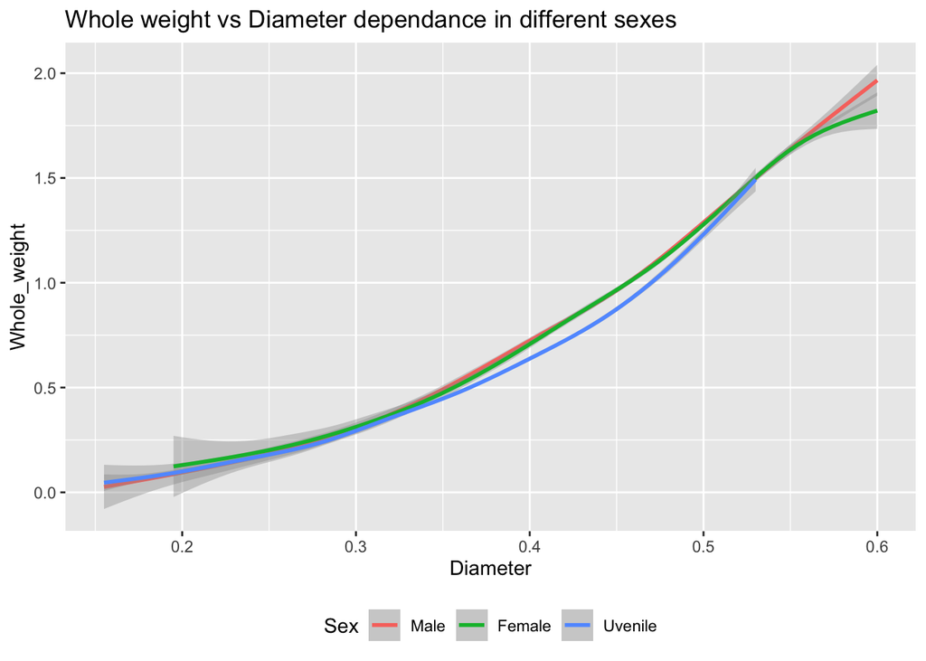

```r
ggplot(Mollusca, aes(x = Diameter, y = Whole_weight, col = Sex))+
  geom_smooth()+
  labs(title = "Whole weight vs Diameter dependance in different sexes")+
  theme(legend.position = "bottom")
```

```r
Mollusca %>% group_by(Sex) %>% select(Length, Whole_weight) %>% summarise_each(funs(mean, sd)) # 3
```

```
## # A tibble: 3 x 5
##   Sex     Length_mean Whole_weight_mean Length_sd Whole_weight_sd
##   <fct>         <dbl>             <dbl>     <dbl>           <dbl>
## 1 Male          0.558             0.955    0.0954           0.413
## 2 Female        0.576             1.02     0.0838           0.398
## 3 Uvenile       0.438             0.446    0.0982           0.277
```

```r
small <- Mollusca %>% filter(Height < 0.165)
percent_of_small <- nrow(small) / nrow(Mollusca) *100 #4

quantile_vec <- quantile(Mollusca$Length,c(0,0.25,0.5,0.75, 0.921, 1))
print(quantile_vec[5])
```

```
## 92.1%
##  0.66
```

Создадим стандартизированную переменную для длины и сравним диаметр двух групп животных, молодые и взрослые моллюски. Расчитаем тест Мана-Уитни для выяснения достоверности отличий по диаметру между моллюсками разного возраста. Как мы видим из данных теста, диаметры этих двух групп достоверно отличаются друг от друга (ответ на 6 и 7 вопрос задания)

```r
Mollusca$Lenght_z_scores <- scale(Mollusca$Length, center = TRUE, scale = TRUE) #6
 y_Diam <- Mollusca %>% filter(Rings == 5) %>% select(Diameter)
 o_Diam <- Mollusca %>% filter(Rings == 15) %>% select(Diameter)
 wilcox.test(o_Diam$Diameter, y_Diam$Diameter) #7
```

```
##
##  Wilcoxon rank sum test with continuity correction
##
## data:  o_Diam$Diameter and y_Diam$Diameter
## W = 10199, p-value < 2.2e-16
## alternative hypothesis: true location shift is not equal to 0
```

### Оценка достоверности различий в показателях в зависимости от возраста и пола

Построим графики зависимости диаметра и веса от возраста и пола. С помощью критерия Крускела-Уоллиса оценим разницу между полами по показателям в каждой возрастной группе. В случае достоверных различий по критерию Крускела-Уоллиса, оценим различия между группами с помощью теста Данна.

```r
age_groups <- c("baby", "young","adult","old")
list_kt_D <- lapply(age_groups, function(i) {kruskal.test(Mollusca$Diameter ~ Mollusca$Sex, subset= Mollusca$Age ==i )})
names(list_kt_D) <- age_groups
lst_Dt_D <- lapply(age_groups, function(i) {DunnTest(Mollusca$Diameter ~ Mollusca$Sex, subset= Mollusca$Age ==i )})
names(lst_Dt_D) <- age_groups
print(lst_Dt_D)
```

```
## $baby
##
##  Dunn's test of multiple comparisons using rank sums : holm
##
##                mean.rank.diff   pval
## Female-Male          33.47727 0.3914
## Uvenile-Male          5.31348 0.6569
## Uvenile-Female      -28.16379 0.3914
## ---
## Signif. codes:  0 '***' 0.001 '**' 0.01 '*' 0.05 '.' 0.1 ' ' 1
##
##
## $young
##
##  Dunn's test of multiple comparisons using rank sums : holm
##
##                mean.rank.diff    pval
## Female-Male          128.8243 0.00064 ***
## Uvenile-Male        -735.8740 < 2e-16 ***
## Uvenile-Female      -864.6983 < 2e-16 ***
## ---
## Signif. codes:  0 '***' 0.001 '**' 0.01 '*' 0.05 '.' 0.1 ' ' 1
##
##
## $adult
##
##  Dunn's test of multiple comparisons using rank sums : holm
##
##                mean.rank.diff    pval
## Female-Male          37.16929  0.0716 .
## Uvenile-Male       -258.44650 1.2e-15 ***
## Uvenile-Female     -295.61579 < 2e-16 ***
## ---
## Signif. codes:  0 '***' 0.001 '**' 0.01 '*' 0.05 '.' 0.1 ' ' 1
##
##
## $old
##
##  Dunn's test of multiple comparisons using rank sums : holm
##
##                mean.rank.diff   pval
## Female-Male         -1.956655 0.8362
## Uvenile-Male       -46.558569 0.0094 **
## Uvenile-Female     -44.601914 0.0094 **
## ---
## Signif. codes:  0 '***' 0.001 '**' 0.01 '*' 0.05 '.' 0.1 ' ' 1
```

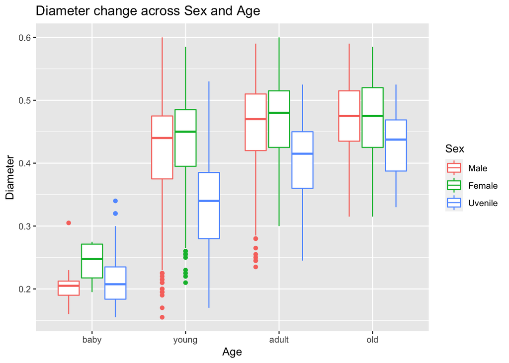

```r
ggplot(Mollusca, aes(x = Age, y = Diameter, col = Sex))+
    geom_boxplot()+
    labs(title ="Diameter change across Sex and Age" )
```

```r
list_kt_W <- lapply(age_groups, function(i) { kruskal.test(Mollusca$Whole_weight ~ Mollusca$Sex, subset= Mollusca$Age ==i )})
names(list_kt_W) <- age_groups
lst_Dt_W <- lapply(age_groups, function(i) { DunnTest(Mollusca$Whole_weight ~ Mollusca$Sex, subset=Mollusca$Age ==i)})
names(lst_Dt_W) <- age_groups
print(lst_Dt_W)
```

```
## $baby
##
##  Dunn's test of multiple comparisons using rank sums : holm
##
##                mean.rank.diff   pval
## Female-Male         32.363636 0.4327
## Uvenile-Male         7.764498 0.5167
## Uvenile-Female     -24.599138 0.4327
## ---
## Signif. codes:  0 '***' 0.001 '**' 0.01 '*' 0.05 '.' 0.1 ' ' 1
##
##
## $young
##
##  Dunn's test of multiple comparisons using rank sums : holm
##
##                mean.rank.diff   pval
## Female-Male          123.4439 0.0011 **
## Uvenile-Male        -791.3677 <2e-16 ***
## Uvenile-Female      -914.8116 <2e-16 ***
## ---
## Signif. codes:  0 '***' 0.001 '**' 0.01 '*' 0.05 '.' 0.1 ' ' 1
##
##
## $adult
##
##  Dunn's test of multiple comparisons using rank sums : holm
##
##                mean.rank.diff   pval
## Female-Male          21.36608 0.3005
## Uvenile-Male       -284.68569 <2e-16 ***
## Uvenile-Female     -306.05177 <2e-16 ***
## ---
## Signif. codes:  0 '***' 0.001 '**' 0.01 '*' 0.05 '.' 0.1 ' ' 1
##
##
## $old
##
##  Dunn's test of multiple comparisons using rank sums : holm
##
##                mean.rank.diff   pval
## Female-Male         -2.866055 0.7621
## Uvenile-Male       -39.226415 0.0384 *
## Uvenile-Female     -36.360360 0.0410 *
## ---
## Signif. codes:  0 '***' 0.001 '**' 0.01 '*' 0.05 '.' 0.1 ' ' 1
```

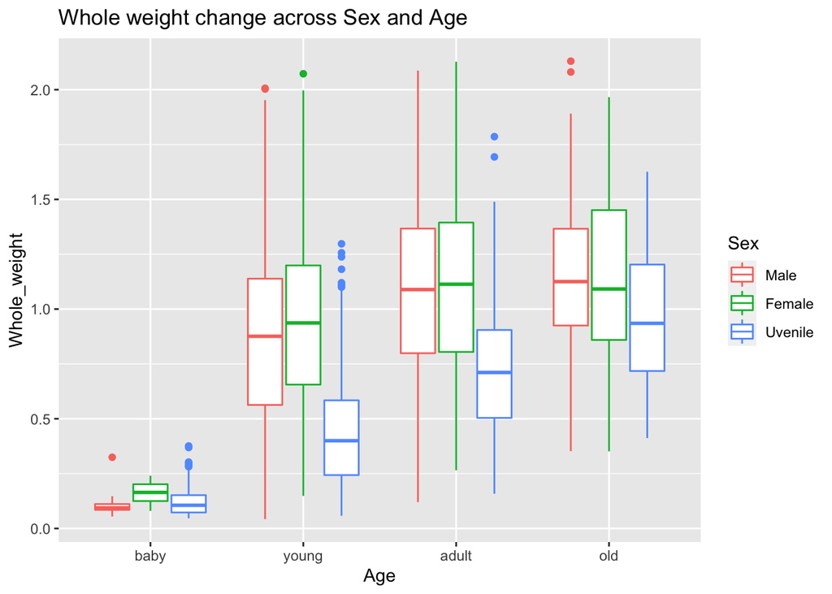

```r
ggplot(Mollusca, aes(x = Age, y = Whole_weight, col = Sex))+
   geom_boxplot()+
   labs(title ="Whole weight change across Sex and Age" )
```

Как можно понять из приведенных даных, диаметр и вес моллюсков значимо отличаются во всех возрастных группах, кроме совсем молодых животных (группа “baby”) между половозрелыми и неполовозрелыми животными. Отличия между самцами и самками наблюдаются только в группе юных животных (“young”).

### Попытка построить линейную модель зависимости веса мидий от размера, возраста и пола

Попробуем построить модель зависимости общего веса моллюска от размера, возрас и пола. Такая модель могла бы предсказывать потенциальный “урожай” моллюсков как диких популяций, так и на аквафермах. Логично предположить, что вес моллюска пропорционален его размеру, а если быть точнее - объему. Введем новую переменную Vol - в которую занесем объемы наших мидий, расчитанные по формуле Vol = 4 * 3.14 * (Diameter * Length * Height)/3 - формула объема эллипсоида. Т.к. все переменные в нашем датасете имеют ненормальное распределение, то переведем нашу зависимую переменную Whole_weight и независимую Vol в стандартизованную форму (Weight_z, Vol_z). Построим линейную модель зависимости стандартизованного веса от стандартизованной длинны, пола и возраста моллюска. Назовем эту модель - model_1. Вторую модель построим без учета фактора пола (model_2), т.к. полученные выше данные говорят о том, что пол сам по себе слабо влияет на параметры веса и размера, важна половозрелость.

```r
Mollusca$Weight_z <- scale(Mollusca$Whole_weight, center = TRUE, scale = TRUE)
Mollusca$Vol <- 4*3.14*(Mollusca$Length*Mollusca$Diameter*Mollusca$Height)/3
Mollusca$Vol_z <- scale(Mollusca$Vol, center = T, scale = T)
model_1 <- lm( Weight_z ~ Vol_z + Age + Sex , data = Mollusca)
model_2 <- lm(Weight_z ~ Vol_z + Age  , data = Mollusca)
vif_coef_mod1 <- VIF(model_1)
print(vif_coef_mod1)
```

```
##           GVIF Df GVIF^(1/(2*Df))
## Vol_z 1.641405  1        1.281173
## Age   1.338064  3        1.049734
## Sex   1.456373  2        1.098546
```

```r
summary(model_1)
```

```
##
## Call:
## lm(formula = Weight_z ~ Vol_z + Age + Sex, data = Mollusca)
##
## Residuals:
##      Min       1Q   Median       3Q      Max
## -1.28965 -0.13306 -0.01503  0.11333  1.72258
##
## Coefficients:
##              Estimate Std. Error t value Pr(>|t|)
## (Intercept) -0.005617   0.023800  -0.236   0.8134
## Vol_z        0.939787   0.005028 186.895   <2e-16 ***
## Ageyoung     0.058015   0.023061   2.516   0.0119 *
## Ageadult     0.043375   0.024936   1.739   0.0820 .
## Ageold       0.036876   0.028956   1.274   0.2029
## SexFemale   -0.018671   0.009585  -1.948   0.0515 .
## SexUvenile  -0.122504   0.010852 -11.289   <2e-16 ***
## ---
## Signif. codes:  0 '***' 0.001 '**' 0.01 '*' 0.05 '.' 0.1 ' ' 1
##
## Residual standard error: 0.2483 on 3997 degrees of freedom
## Multiple R-squared:  0.9384, Adjusted R-squared:  0.9383
## F-statistic: 1.015e+04 on 6 and 3997 DF,  p-value: < 2.2e-16
```

```r
vif_coef_mod2 <- VIF(model_2)
print(vif_coef_mod2)
```

```
##           GVIF Df GVIF^(1/(2*Df))
## Vol_z 1.308102  1        1.143723
## Age   1.308102  3        1.045780
```

```r
summary(model_2)
```

```
##
## Call:
## lm(formula = Weight_z ~ Vol_z + Age, data = Mollusca)
##
## Residuals:
##      Min       1Q   Median       3Q      Max
## -1.29805 -0.12527 -0.02622  0.11604  1.74802
##
## Coefficients:
##              Estimate Std. Error t value Pr(>|t|)
## (Intercept) -0.077273   0.023101  -3.345 0.000831 ***
## Vol_z        0.964521   0.004562 211.436  < 2e-16 ***
## Ageyoung     0.081434   0.023343   3.489 0.000491 ***
## Ageadult     0.078766   0.025138   3.133 0.001741 **
## Ageold       0.069044   0.029280   2.358 0.018420 *
## ---
## Signif. codes:  0 '***' 0.001 '**' 0.01 '*' 0.05 '.' 0.1 ' ' 1
##
## Residual standard error: 0.2524 on 3999 degrees of freedom
## Multiple R-squared:  0.9364, Adjusted R-squared:  0.9363
## F-statistic: 1.472e+04 on 4 and 3999 DF,  p-value: < 2.2e-16
```

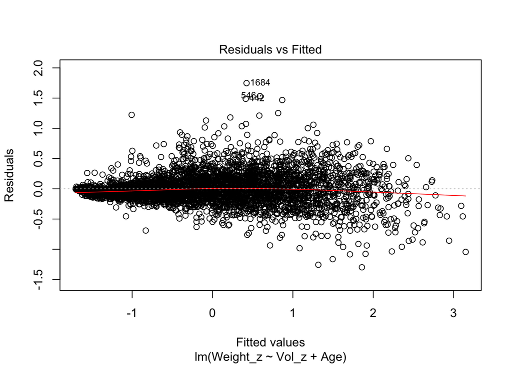

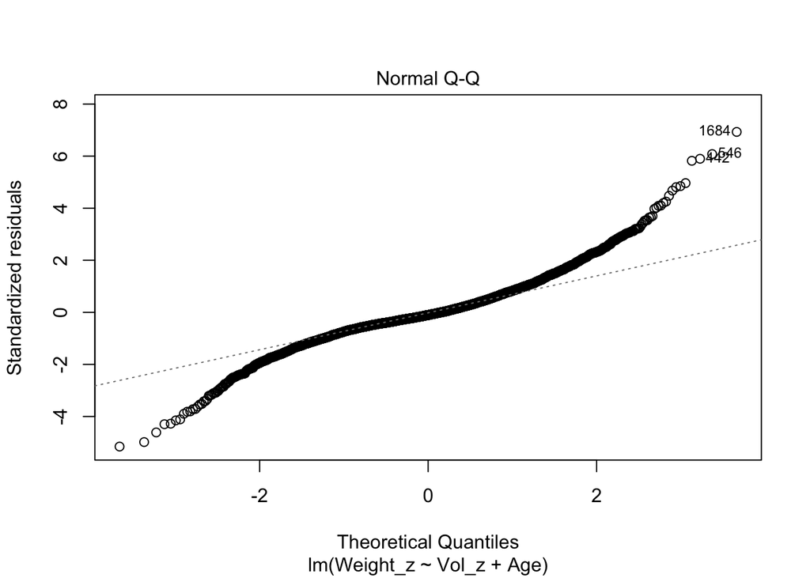

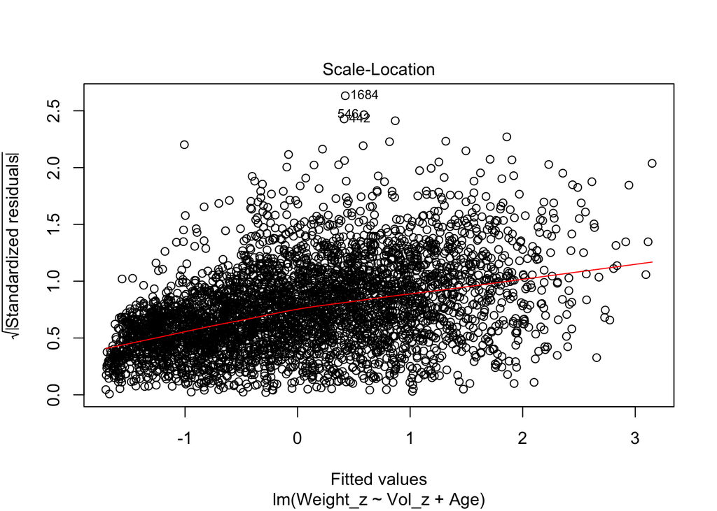

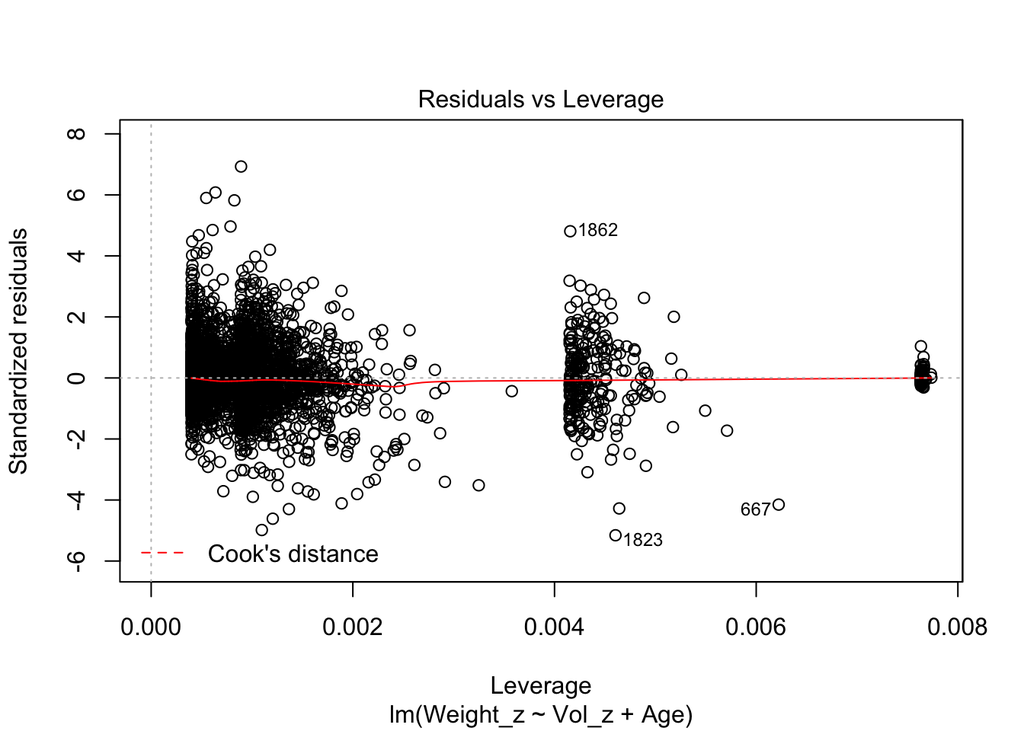

```r
plot(model_2)
```

### Выводы

Подводя итог всему вышеперичисленному можно сделать несколько выводов:

1. Переменные, описывающие вес (Whole_weight, Shucked_weight, Viscera_weight, Shell_weight), также как и переменные, описывающие размер (Diameter, Length, Hight) демонстрируют сильную корреляцию внутри групп и между собой.
2. Возраст демоснтрирует слабую и среднюю корреляцию с переменными размера и веса. Наибольшая корреляция наблюдается между возрастом и весом раковины моллюска. 3. При оценке влияния пола в различных возрастных группах было выявлено, что достоверная разница в диаметре и общем весе моллюска наблюдается между половозрелыми и неполовозрелыми особями во всех возрастных группах, кроме совсем молодых особей (моложе 6 лет). Показатели неполовозрелых особей значительно ниже, чем показатели половозрелых.
3. Достоверная разница в диаметре и общем весе между самцами и самками показана только в группе молодых животных (6-10 лет). Показатели самок выше, чем показатели самцов.
4. На основе имеющихся данных нельзя построить линейную модель зависимости веса моллюсков от их размера, возраста или пола т.к. абсолютно все переменные нашего датасета характеризуются ненормальным распределением, более того, дисперсия признаков увеличивается в зависимости от возраста и пола, что также не позволяет нам построить адекватную линейную модель.